# Contactor Simulation

Alejandro Zúñiga Pérez

2/8/2021

# Electrical Machines Modelling

The present python script is a numerical, electrical and computarized simulation of a magnetic contactor used in different real applications. In this case, it is solved using fenics, dolfin and mshr libraries, all included inside python importing.

So let’s begin. First we need to import all the needed modules.

```python
from fenics import *
from mshr import *
import numpy as np
import matplotlib.pyplot as plt
import dolfin.common.plotting as mshplot
import sys
```

Next, we define our needed functions, in this case, there is a function created for returning the sum of two points in a bidimensional plane.

But previously, we set a variable that represents the distance between the bottom fixed structure of the contactor and the upper movable core of the element.

```python
dist = 0.4
```

```python
def sum_points(x1, x2):
    ''' Returns vector sum of two points. '''

    return (x1[0] + x2[0], x1[1] + x2[1])
```

One of the main functions is presented below, we use this function to transform a path with relative coordinates into one with absolute coordinates.

```python
def draw_path(rel_coords, origin=(0, 0)):

    last_coord = rel_coords[0]
    abs_coords = [last_coord]
    for coord in rel_coords[-len(rel_coords)+1::]:
        next_coord = sum_points(last_coord, coord)
        abs_coords.append(next_coord)
        last_coord = next_coord

    return abs_coords
```

Then we set a third function that modifies path with absolute coordinates so that the first coordinate matches a given point (origin) and distances are preserved.

```python
def shift_origin(coords, origin=(0,0)):
    offset = (origin[0] - coords[0][0], origin[1] - coords[0][1])

    return [sum_points(offset, coord) for coord in coords]
```

Next, we define some variables corresponding to each contactor parameter given its values on a research paper.

```python
thickness = 0.8
la = 1.6
lb = 1.05
center_thickness = 1.1
ring_depth = 0.15
ring_width = 0.1
ring_sep = 0.1
center_gap = 0.04
```

Given the values, we proceed to define the main vertices in order to plot a mesh with the contactor geometry.

```python
rel_vertices=[(0, 0),
              (2*thickness + 2*lb + center_thickness, 0),
              (0, thickness + la),
              (-ring_sep, 0),
              (0, -ring_depth),
              (-ring_width, 0),
              (0, ring_depth),
              (-thickness + 2*ring_width + 2*ring_sep, 0),
              (0, -ring_depth),
              (-ring_width, 0),
              (0, ring_depth),
              (-ring_sep, 0),
              (0, -la),
              (-lb, 0),
              (0, la - center_gap),
              (-center_thickness, 0),
              (0, -la + center_gap),
              (-lb, 0),
              (0, la),
              (-ring_sep, 0),
              (0, -ring_depth),
              (-ring_width, 0),
              (0, ring_depth),
              (-thickness + 2*ring_width + 2*ring_sep, 0),
              (0, -ring_depth),
              (-ring_width, 0),
              (0, ring_depth),
              (-ring_sep, 0)]
```

In order to keep the code working good so far, we decide to print the main vertices defined previously.

```python
abs_vertices = draw_path(rel_vertices)
shifted_vertices = shift_origin(abs_vertices, origin=(1, 3.4 - dist - la - thickness))
points = [Point(v) for v in shifted_vertices]
print(shifted_vertices)
```

[output not shown]

Now, we proceed to define the upper vertices corresponding the movable part of the contactor.

```python
upper_vertices = [Point(5.8, 5.8),
                Point(1, 5.8),
                Point(1,3.4),
                Point(1.8, 3.4),
                Point(1.8, 5),
                Point(2.85, 5),
                Point(2.85, 3.4),
                Point(3.95, 3.4),
                Point(3.95, 5),
                Point(5, 5),
                Point(5, 3.4),
                Point(5.8, 3.4)]
```

After the previous steps, we proceed to import some of the dolfin functions for plotting rectangles and circles.

```python
domain = Circle(Point(1+thickness+lb+0.5*center_thickness,3.4-0.5*dist),10)
```

```python
winding_sep = 0.1*lb
winding = [(0, 0),
           (lb - 2*winding_sep, 0),
           (0, la - 2*winding_sep),
           (-lb + 2*winding_sep, 0)]


left_winding = shift_origin(draw_path(winding),
                            origin=(1 + thickness + winding_sep, 3.4 - dist - la + winding_sep))
right_winding = shift_origin(draw_path(winding),
                             origin=(1 + thickness + winding_sep + lb + center_thickness, 3.4 - dist - la + winding_sep))

left_points = [Point(v) for v in left_winding]
right_points = [Point(v) for v in right_winding]

wire1 = Polygon(left_points)
wire2 = Polygon(right_points)


circuit = Polygon(points) + Polygon(upper_vertices) + wire1 + wire2
domain.set_subdomain(1, circuit)
domain.set_subdomain(2, wire1)
domain.set_subdomain(3, wire2)
```

Now, it is time to define the mesh of the contactor.

```python
msh = generate_mesh(circuit, 24)
plot(msh)
plt.axis([0.5, 6.3, 0.5, 6.3])
```

```
## (0.5, 6.3, 0.5, 6.3)
```

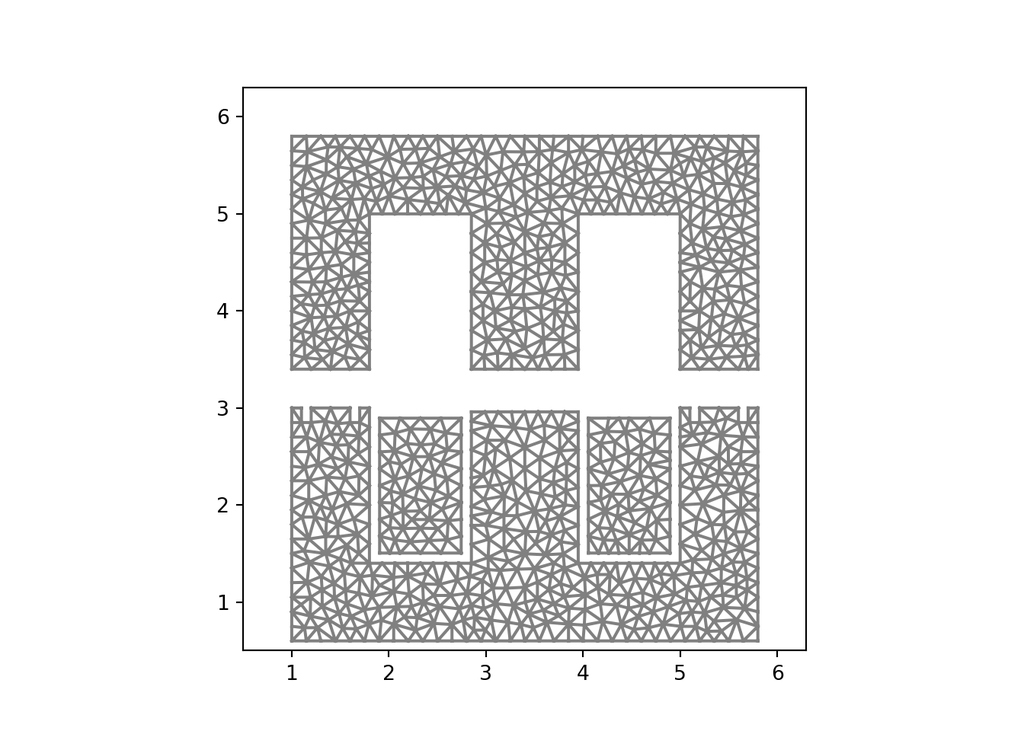

```python
plt.show()
```

```python
mesh = generate_mesh(domain, 32)
```

## Defining the numerical method

This is a clue key to simulate the contactor, and in order to keep it correctly working, it is necessary to set some magnetic parameters.

```python
V = FunctionSpace(mesh, 'P', 1)

bc = DirichletBC(V, Constant(0), 'on_boundary')


markers = MeshFunction('size_t', mesh, 2, mesh.domains())
dx = Measure('dx', domain=mesh, subdomain_data=markers)


J_N = Constant(2*1100e1/(1.4*0.7))
J_S = Constant(-2*1100e1/(1.4*0.7))
```

As a next step, it is necessary to define the magnetic permeability.

```python
class Permeability(UserExpression):
    def __init__(self, markers, **kwargs):
        super(Permeability, self).__init__(**kwargs)
        self.markers = markers

    def eval_cell(self, values, x, cell):
        if self.markers[cell.index] == 0:
            # Air
            values[0] = 4*pi*1e-7
        elif self.markers[cell.index] == 1:
            # Iron
            values[0] = 6.3e-3
        else:
            # Copper
            values[0] = 1.26e-6

    def value_shape(self):
        return ()
```

Now, we call this class to save its data into a variable called mu.

```python
mu1 = Permeability(markers, degree=1)
```

Time to solve the magnetic problem.

```python
A_z = TrialFunction(V)
v = TestFunction(V)
a = (1 / mu1)*dot(grad(A_z), grad(v))*dx
L_N = J_N*v*dx(2)
L_S = J_S*v*dx(3)
L = L_N + L_S
```

```python
A_z = Function(V)
solve(a == L, A_z, bc)
```

```python
W = VectorFunctionSpace(mesh, 'P', 1)
B = project(as_vector((A_z.dx(1), -A_z.dx(0))), W)

ax = plt.axes()
```

Let’s see the results. First, we plot the magnetic field vector.

```python
mshplot.plot(mesh, linewidth=0.2)
c = plot(B)
plt.axis([0.5, 6.3, 0.5, 6.3])
```

```
## (0.5, 6.3, 0.5, 6.3)
```

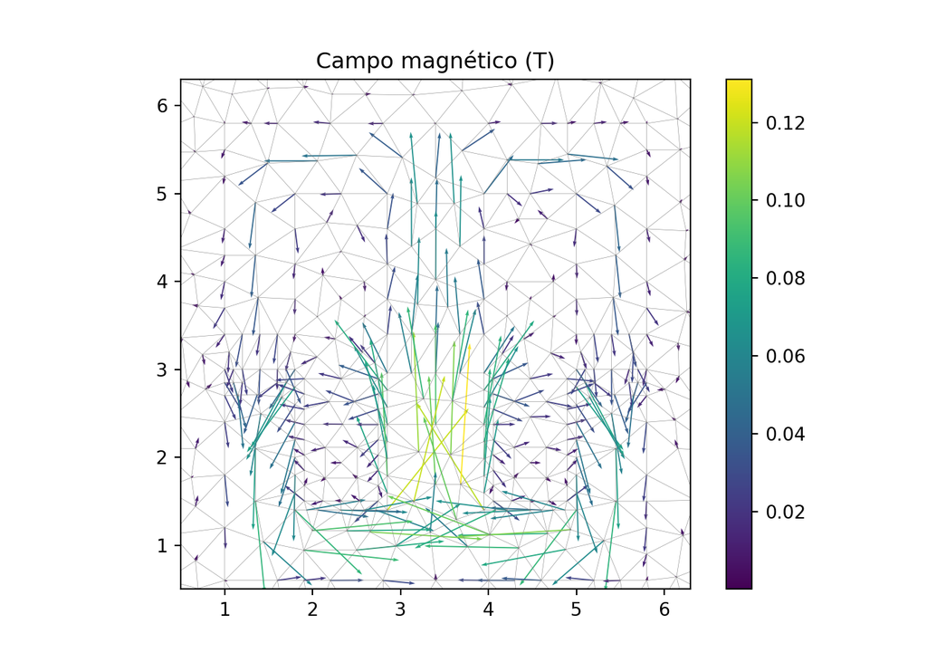

```python
plt.title('Campo magnético (T)')
plt.colorbar(c)
plt.show()
```

Second, we plot the magnetic field magnitude.

```python
Bx =  A_z.dx(1)
By = -A_z.dx(0)
B_abs = np.power(Bx**2 + By**2, 0.5)

abs_B = FunctionSpace(mesh, 'DG', 0)
f = B_abs


w_h = TrialFunction(abs_B)
v = TestFunction(abs_B)
a = w_h*v*dx
L = f*v*dx


w_h = Function(abs_B)
solve(a == L, w_h)
```

```python
mshplot.plot(mesh, linewidth=0.2)
c = plot(w_h)
plt.axis([0.5, 6.3, 0.5, 6.3])
```

```
## (0.5, 6.3, 0.5, 6.3)
```

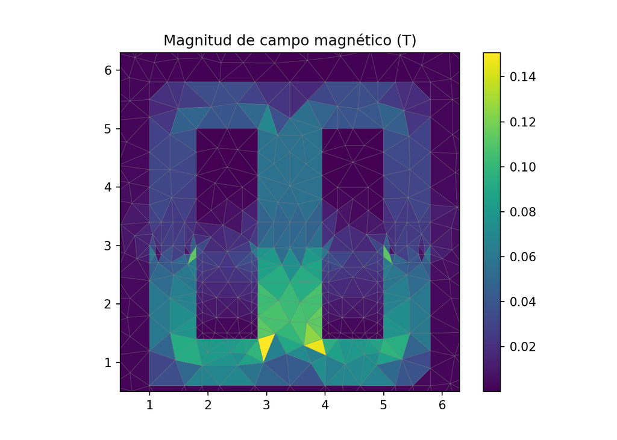

```python
plt.title('Magnitud de campo magnético (T)')
plt.colorbar(c)
plt.show()
```